# Coursework Report

*N* removed NAs: 2

*N* removed typo: 1

*N* removed <18: 22

*N* total clean: 125

| Group | *N* | *M*<sub>age</sub> | *M*<sub>rating</sub> |
| --- | --- | --- | --- |
| Control | 57 | 20.18 | 6.96 |
| Experim | 68 | 20.54 | 5.88 |

**Main analysis results**

*t*(123) = 7.29, *p* < .001

[interactive chart not shown]

[figure not shown]

[interactive chart not shown]

# Coursework Report

Analysing Data, Spring 2020

# Methods

## Participants

Table 1, Descriptive Statistics by Participants Age

| Mean Age | SD of Age | Minimum Age | Maximum Age |
| --- | --- | --- | --- |
| 20.38 | 1.6 | 18 | 25 |

Table two shows the final participants descriptive by experimental condition

Table 2, Descriptive statistics by Group

| Group | N | Mean Age | SD of Age |
| --- | --- | --- | --- |
| control | 57 | 20.18 | 1.57 |
| experimental | 68 | 20.54 | 1.62 |

## Design

This study examined the effect of colour on a human attractiveness. The study used a standardised moderately attractive man on either a white or a red background. The factor of colour was the independent variable. This variable was manipulated by the researcher by randomly assigning the female participants to either viewing the black and white photo on a red (experimental condition) or a white background (control condition) for a time period of 5 seconds. White was chosen as Elliot et al (2010) considered it to be a neutral colour. Participants were then asked to report their perceptions of the man in the photos’ attractiveness. The attractiveness score was a rating the participant gave from 1-9 based on the three questions: how attractive do you think this person is?, how pleasant is this person to look at?, if I were to meet the person in this picture face to face, I would think he is attractive. The higher the participants score indicated the more attractive the female participant found the male in the picture. The combined participants ratings were used to create a mean composite score for each participant.

This study manipulated the colour of the background behind a photo of a man and asked female participants to rate his attractiveness. An independent *t*-test will be used to statistically analyse whether the experimental results found are statistically significant.

# Results

This study investigated whether female participants would be more attracted to men in conjunction with the colour red or to the control colour white. The general pattern of results shows a higher attractiveness rating to the control group compared to the experimental. Table 3 shows the descriptive statistics by questions.

Table 3, Descriptive Statistics by Questions

| Group | Question 1 Mean | Question 1 SD | Question 2 Mean | Question 2 SD | Question 3 Mean | Question 3 SD |
| --- | --- | --- | --- | --- | --- | --- |
| control | 7.12 | 1.43 | 6.82 | 1.44 | 6.95 | 1.26 |
| experimental | 6.13 | 1.35 | 5.91 | 1.57 | 5.60 | 1.41 |

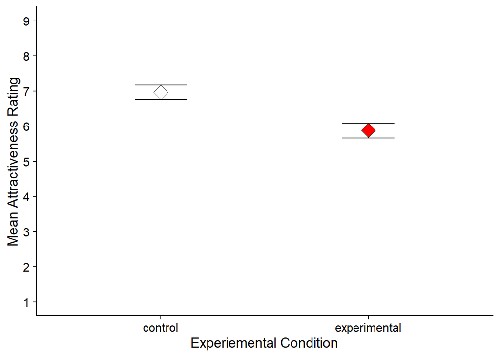

# Discussion

This research aimed to investigate the colour reds influence on a women’s attractiveness ratings towards a moderately attractive male. The results of this study do not match the pattern found in Elliot et al’s (2010) original study. Elliot et al (2010) found that colours did influence participants ratings of attractiveness. Meanwhile, the present study found the adverse effect with the control group being rated significantly more attractive than the red group, thus suggesting that red does not have a positive effect on attractiveness. Researchers are often conflicted regarding red’s effect on attractiveness. Biologically, it is believed that red is linked to qualities such as strength and dominance (Little and Hill, 2007). Thus, red can link to highly oxygenated haemoglobin levels which portrays high levels of testosterone within men, arguably making them more attractive as a mate to reproduce with (Elliot et al, 2010). However, other research demonstrates that the colour reds link with dominance does not mean attractiveness. For example, Wiedemann (2015) study argues that when red is associated with a man, he is seen to be more aggressive and angry. These traits were seen as undesirable in a male partner in Lippa’s (2007) study, whilst qualities such as honesty, humour and kindness were ranked more important. Therefore, it may be that the colour red does not enhance attractiveness as the colour itself has negative connotations when associated with men.

Furthermore, a later study based on Elliot’s paradigm did not find any significant impact of the colour red on attractiveness ratings (Hesslinger, Goldbach & Carbon, 2015). Therefore, this research partnered with the current study suggests that there is not as strong evidence for reds effect of women’s attraction to men as Elliot et als (2010) research suggests. Thus, future research should focus on questioning if the effect found was because of the negative connotations surrounding the colour red, or conversely if it was significant that the colour white was used as the control condition. Therefore, future studies should introduce a variety of colours to assess what colour is associated with the highest level of attraction. Furthermore, future research could link these colours to personality traits, such as reds to anger.

A limitation of this experiment is that it used a small sample, 25 participants were removed from the original 150 sampled for ethical reasons, thus making the sample smaller. To gain a representative and more generalisable set of results, the experiment should be conducted on a larger sample size. Furthermore, the study was conducted on female undergraduates thus a variety of ages should be used to gather more representative findings.

To conclude, the present study found that the control group was rated significantly higher in attractiveness than the experimental red group. Therefore, this research questions Elliot et al’s previous finding that red has a positive impact of attractiveness rating. This research found that the control group have a significantly higher attractiveness ratings than the red experimental group.

# References

Elliot, A., Niesta Kayser, D., Greitemeyer, T., Lichtenfeld, S., Gramzow, R., Maier, M., & Liu, H. (2010). Red, rank, and romance in women viewing men. *Journal of Experimental Psychology: General, 139*(3), 399-417.

Hesslinger, V., Goldbach, L., & Carbon, C. (2015). Men in red: A reexamination of the red-attractiveness effect. Psychonomic Bulletin & Review, 22(4), 1142-1148

Lippa, R. (2007). The Preferred Traits of Mates in a Cross-National Study of Heterosexual and Homosexual Men and Women: An Examination of Biological and Cultural Influences. Archives Of Sexual Behavior, 36(2), 193-208.

Wiedemann, D., Burt, D., Hill, R., & Barton, R. (2015). Red clothing increases perceived dominance, aggression and anger. Biology Letters, 11(5)